# Case Study 3 - Identifying Spam

Martin Garcia, Michael Catalano, Jeremy Otsap, Christian Nava

6/3/2020

#### Required packages

```r
library(rpart) # package for our CART model
library(rpart.plot) # plots our CART model
library(RColorBrewer) # used for color schemes
library(rattle)
library(caret) # used for datapartition function & tuning
library(tidyverse) # used to ggplot
library(ROCR) #used for our ROC curve
library(summarytools) # our EDA tool
library(recipes) #used for knn imputation function
library(gghighlight) #used to highlight specific visuals
```

We observe 9348 emails in this classification problem to identify spam given 29 predictor variables.

The predictor variables characterize our email header and body and include factor level data such as isDear which tells us if the word dear is in the email body and also other non-categorical variables like numLines which is discrete values for the number of lines in each of our email examples. We search for Spam in a body of emails containing ham, which is not spam.

Note spam emails are identified with the value T and ham as F. Our response is binary which warrants a categorical approach with CART using Rpart. A definition summary of the predictor variables is found below.

```r
str(emailDFrp)
```

```
## 'data.frame':    9348 obs. of  30 variables:
##  $ isSpam       : Factor w/ 2 levels "F","T": 1 1 1 1 1 1 1 1 1 1 ...
##  $ isRe         : Factor w/ 2 levels "F","T": 2 1 1 1 2 2 1 2 1 2 ...
##  $ underscore   : Factor w/ 2 levels "F","T": 1 1 1 1 1 1 1 1 1 1 ...
##  $ priority     : Factor w/ 2 levels "F","T": 1 1 1 1 1 1 1 1 1 1 ...
##  $ isInReplyTo  : Factor w/ 2 levels "F","T": 2 1 1 1 1 2 1 1 1 2 ...
##  $ sortedRec    : Factor w/ 2 levels "F","T": 2 2 2 2 2 2 2 2 2 2 ...
##  $ subPunc      : Factor w/ 2 levels "F","T": 1 1 1 1 1 1 1 1 1 1 ...
##  $ multipartText: Factor w/ 2 levels "F","T": 1 1 1 1 1 1 1 1 1 1 ...
##  $ hasImages    : Factor w/ 2 levels "F","T": 1 1 1 1 1 1 1 1 1 1 ...
##  $ isPGPsigned  : Factor w/ 2 levels "F","T": 1 1 1 1 1 1 1 1 1 1 ...
##  $ subSpamWords : Factor w/ 2 levels "F","T": 1 1 1 1 1 1 1 1 1 1 ...
##  $ noHost       : Factor w/ 2 levels "F","T": 1 1 1 1 1 1 1 1 1 1 ...
##  $ numEnd       : Factor w/ 2 levels "F","T": 1 1 1 1 1 1 1 1 1 1 ...
##  $ isYelling    : Factor w/ 2 levels "F","T": 1 1 1 1 1 1 1 1 1 1 ...
```

[output cut: 16 more lines]

We split our data into an 80/20 split consisting of a training and test set not as a sampling method but in order to model our training data with cross validation and assume the test set is a brand new data set we want to test with for accuracy.

```r
set.seed(1) #reproducibility
#split our data with createDataPartition with caret into an 80-20 split, training and test respectively
split_index <- createDataPartition(emailDFrp$isSpam, p=.8,list = FALSE, times=1)

#training and test sets
training <- emailDFrp[ split_index,] #use index to refer to training set from our sample
testing <- emailDFrp[-split_index,] #use index to refer to our test set from our sample
```

Several variables have missing values, particularly numRec, or the number of receipients in the email. This justifies imputation for our data.

```r
sapply(training, function(x) sum(is.na(x)))
```

```
##        isSpam          isRe    underscore      priority   isInReplyTo
##             0             0             0             0             0
##     sortedRec       subPunc multipartText     hasImages   isPGPsigned
##             0             0             0             0             0
##  subSpamWords        noHost        numEnd     isYelling     isOrigMsg
##             5             1             0             5             0
##        isDear       isWrote      numLines    bodyCharCt      subExcCt
##             0             0             0             0            14
##     subQuesCt        numAtt        numRec       perCaps          hour
##            14             0           223             0             0
##       perHTML     subBlanks      forwards    avgWordLen        numDlr
##             0            14             0             0             0
```

# Data Preparation

### Imputation with the Recipes package

The recipes function is a intuititive way to preprocess our data from scaling, creating dummy variables, and various imputation methods.

For our example we use knn for our imputation method. This will look at the 5 closest neighbors to determine how to fill our empty elements. Like the package name suggest the imputation process is an sequential set of functions that start with a recipe and “bake” our imputation.

We specify our response and predictor variables with the recipe function.

```r
myrecipe <- recipe(isSpam ~ ., data = training)
myrecipe
```

```
## Data Recipe
##
## Inputs:
##
##       role #variables
##    outcome          1
##  predictor         29
```

We define our preprocessing steps, in this case we impute our data via the knn method that looks at the five nearest neighbors.

```r
mysteps <- myrecipe %>%
  step_knnimpute(all_predictors(), neighbors = 5)
  #step_meanimpute()
  #step_modeimpute()
  #step_scale()
  #step_dummy()

mysteps
```

```
## Data Recipe
##
## Inputs:
##
##       role #variables
##    outcome          1
##  predictor         29
##
## Operations:
##
## K-nearest neighbor imputation for all_predictors
```

We provide the data we want to run through our preprocessing step, in this case step_knnimpute for our knn imputation.

```r
impute_prep <- prep(mysteps, training = training) # can apply to test as well
```

We apply our steps to our data with the bake function to both our training and test sets.

```r
training <- bake(impute_prep, training)
testing <- bake(impute_prep, testing)
```

We double check our test and training data for missing values.Voila! An imputed data set.

```r
sapply(training, function(x) sum(is.na(x)))
```

```
##          isRe    underscore      priority   isInReplyTo     sortedRec
##             0             0             0             0             0
##       subPunc multipartText     hasImages   isPGPsigned  subSpamWords
##             0             0             0             0             0
##        noHost        numEnd     isYelling     isOrigMsg        isDear
##             0             0             0             0             0
##       isWrote      numLines    bodyCharCt      subExcCt     subQuesCt
##             0             0             0             0             0
##        numAtt        numRec       perCaps          hour       perHTML
##             0             0             0             0             0
##     subBlanks      forwards    avgWordLen        numDlr        isSpam
##             0             0             0             0             0
```

### Class imbalance with Caret::Upsample

The number of spam observations is significanly less than our ham emails. We have 1918 spam against 5561 ham emails. We can approach this by decreasing the number of ham emails or increasing the number of spam emails to match the volume of ham. To prevent a reduction in the number of observations we apply the upsample method. This method will increase our spam volume to match our ham volume, resulting in 5561 spam and ham emails.

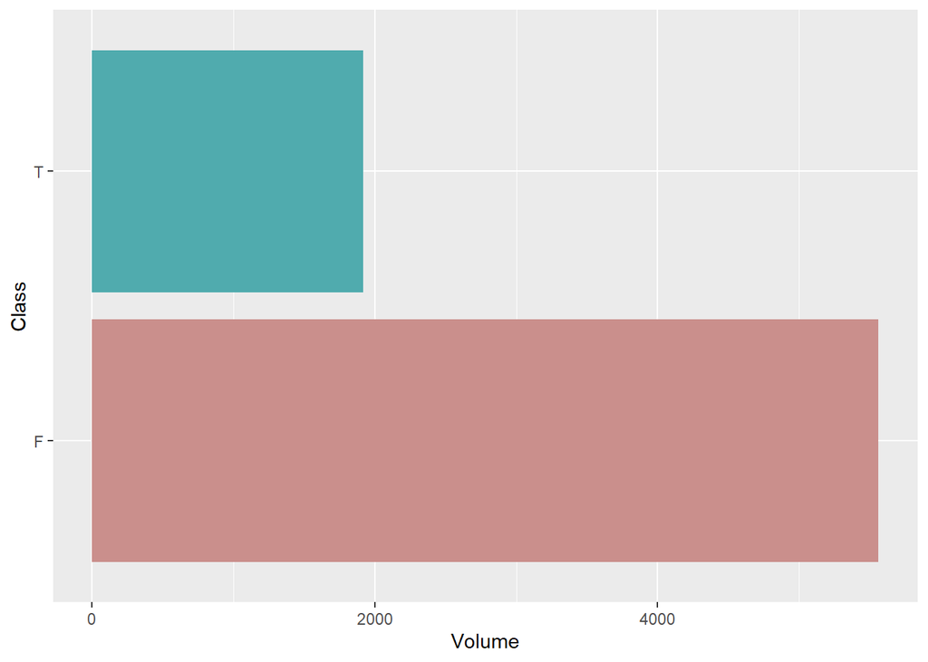

```
##
##    F    T
## 5561 1918
```

The upsample function from Caret increases the number of Spam observations to match our ham emails. The end result is 5561 observations for ham and spam emails.

```r
up_training <- upSample(x = training[, -ncol(training)],
                     y = training$isSpam)

#remove column class as not needed for modeling
#training$Class <- NULL

table(up_training$Class)
```

```
##
##    F    T
## 5561 5561
```

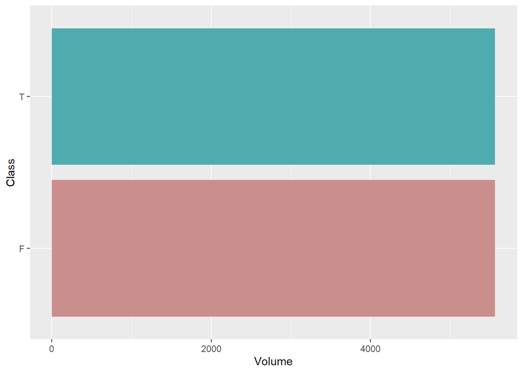

```
##
##    F    T
## 5561 5561
```

# CART Models

### CART Model (Default hyperparameters)

We set benchmarks for our final model by creating a “vanilla” model that trains a decision tree with the default parameters. This includes the hyperparameters below with their respective default values.

- minsplit = 20 - 20 minimum emails required in each node to initiate a split
- minbucket = round(minsplit/3) - 20 emails / 3 emails = 7 minimum number of emails in any of our leaf nodes
- cp = .01 - Complexity parameter used to control the size of our tree
- xval = 10 - 10 fold cross validation
- maxdepth = 30 - reflects 30 depth levels with the root note counted as 0

We will train with both the training set prior to applying the upsample and a separate training set with the upsample function applied.

#### Balanced Class Data Set

[figure not shown]

```r
#we first train on our balanced class data set

up_training <- up_training %>%
  rename(isSpam = Class)
#forwards, 2664, 8458


fit_imbalance <- rpart(isSpam ~ .,
             method="class", data=up_training) #fitting our model with our upsampled training set

print(fit_imbalance)
fancyRpartPlot(fit_imbalance)
```

```
## n= 11122
##
## node), split, n, loss, yval, (yprob)
##       * denotes terminal node
##
## 1) root 11122 5561 F (0.50000000 0.50000000)
##   2) forwards>=4.293395 2664   84 F (0.96846847 0.03153153) *
##   3) forwards< 4.293395 8458 2981 T (0.35244739 0.64755261) *
```

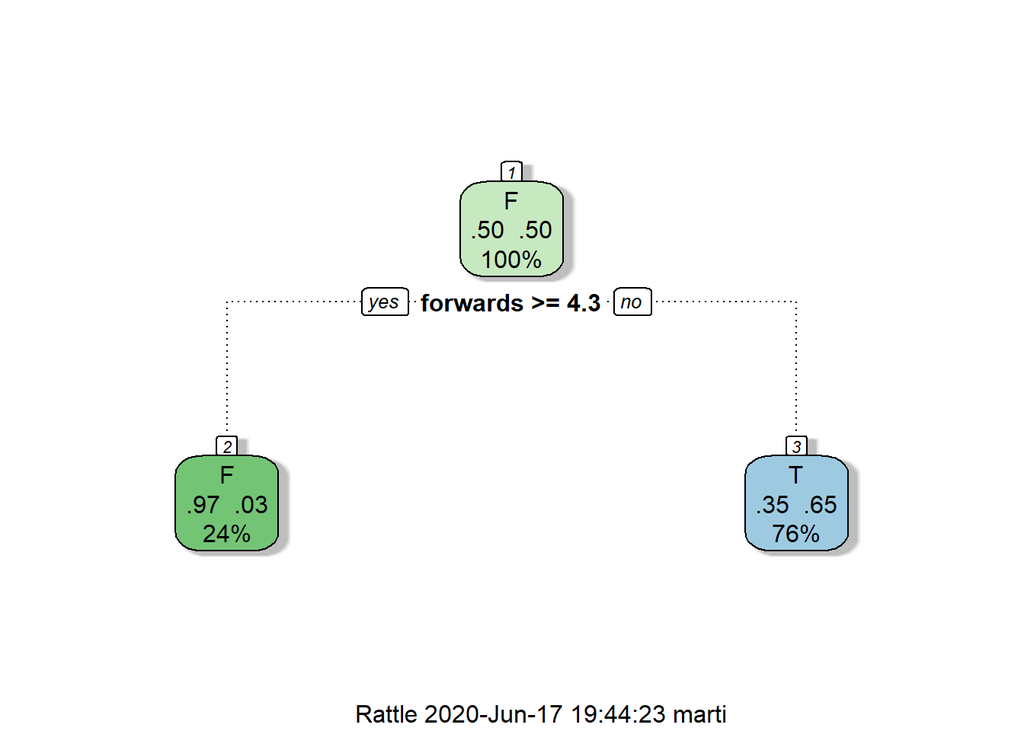

These splits are determined by measuring the purity of the nodes, which looks at the probability of the classes using the formula below we will compute the Ginni. The leaf nodes determine our end result and are not determined by the mean of the node but purity which is more synonymous of the mode of the leaf node. Nodes closer to 0 represent more homogenous nodes and those close to .5 least impure. For our specific example we are trying to identify Spam so we look at probability of selecting spam.

$Gini = 1- P(A \mid B)^{2} - P(B \mid A)^{2}$

$Node 3: .4564 = 1 - (5477/8458)^{2} - (2981/8458)^{2}$

We look at the weighted sum of our Ginis to decide if this an optimal split given this predictor variable against others. This process is done over several other predictor variables with an overall goal of finding the smallest weighted sum to decide on our split.

#### Unbalanced Class Data Set

Fitting our training data without balancing our classeses results in a different tree in terms of number of nodes and depth.

```r
fit <- rpart(isSpam ~ .,
             method="class", data=training) #fitting our model without the upsample training set

print(fit)
```

```
## n= 7479
##
## node), split, n, loss, yval, (yprob)
##       * denotes terminal node
##
##   1) root 7479 1918 F (0.743548603 0.256451397)
##     2) perCaps< 13.05174 6463 1138 F (0.823920780 0.176079220)
##       4) perHTML< 3.926441 5933  786 F (0.867520647 0.132479353)
##         8) forwards>=0.9936055 2706   15 F (0.994456763 0.005543237) *
##         9) forwards< 0.9936055 3227  771 F (0.761078401 0.238921599)
##          18) numDlr< 0.5 2666  465 F (0.825581395 0.174418605)
##            36) subBlanks< 24.97556 2600  399 F (0.846538462 0.153461538)
##              72) subExcCt< 0.5 2460  316 F (0.871544715 0.128455285)
##               144) isDear=F 2428  284 F (0.883031301 0.116968699) *
##               145) isDear=T 32    0 T (0.000000000 1.000000000) *
##              73) subExcCt>=0.5 140   57 T (0.407142857 0.592857143)
##               146) numLines< 18 42    8 F (0.809523810 0.190476190) *
##               147) numLines>=18 98   23 T (0.234693878 0.765306122) *
##            37) subBlanks>=24.97556 66    0 T (0.000000000 1.000000000) *
##          19) numDlr>=0.5 561  255 T (0.454545455 0.545454545)
##            38) numLines>=109.5 142   37 F (0.739436620 0.260563380) *
##            39) numLines< 109.5 419  150 T (0.357995227 0.642004773)
##              78) isInReplyTo=T 33    0 F (1.000000000 0.000000000) *
##              79) isInReplyTo=F 386  117 T (0.303108808 0.696891192) *
##       5) perHTML>=3.926441 530  178 T (0.335849057 0.664150943)
##        10) bodyCharCt>=13538 194   27 F (0.860824742 0.139175258) *
##        11) bodyCharCt< 13538 336   11 T (0.032738095 0.967261905) *
##     3) perCaps>=13.05174 1016  236 T (0.232283465 0.767716535)
##       6) bodyCharCt< 204 88    3 F (0.965909091 0.034090909) *
##       7) bodyCharCt>=204 928  151 T (0.162715517 0.837284483)
##        14) isInReplyTo=T 40    0 F (1.000000000 0.000000000) *
##        15) isInReplyTo=F 888  111 T (0.125000000 0.875000000) *
```

We observe the top nodes and see the tree splits on different variables this time around.This tree begins by splitting our observations based on our variable perCaps, which is the percentage of capital letters in the body of our email. Both nodes 2 is less homogenous than our previous tree. We calculate the Gini to verify this.

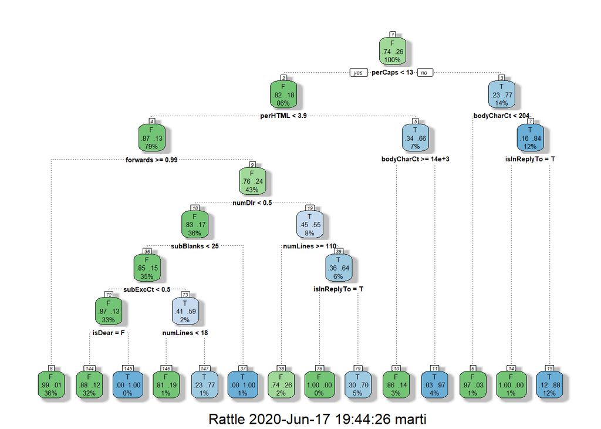

```r
#Decision Tree
fancyRpartPlot(fit)
```

```r
#Pruned decision tree used to illustrate first nodes
pfit2<- prune(fit, cp=.2)
print(pfit2)
```

```
## n= 7479
##
## node), split, n, loss, yval, (yprob)
##       * denotes terminal node
##
## 1) root 7479 1918 F (0.7435486 0.2564514)
##   2) perCaps< 13.05174 6463 1138 F (0.8239208 0.1760792) *
##   3) perCaps>=13.05174 1016  236 T (0.2322835 0.7677165) *
```

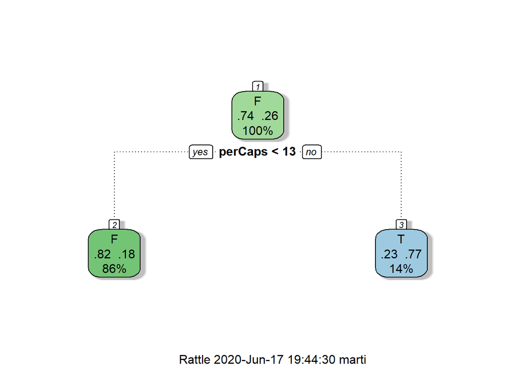

```r
fancyRpartPlot(pfit2)
```

The overall weighted sum of our Ginis results in a smaller value which we want. This translates to a more pure split overall.

$Gini = 1- P(A \mid B)^{2} - P(B \mid A)^{2}$

$Node 2: .29 = 1 - (1138/6463)^{2} - (5325/6463)^{2}$

$Node 3: .356 = 1 - (780/1016)^{2} - (236/1016)^{2}$

**Weight Sum of the Ginis** $= (6463/7479 * .29) + (1016/7479 * .356) = .298$

## Confusion Matrix & Accuracy

We measure how each of these models perform by looking at confusion matrices that can be dissected to evaluate different aspects of our model; True Positive, False Positive, True Negative, and False Negative. The confusion matrix shows all these values and helps us compute the overal accuracy by adding all the values we correctly guessed over the total given by the formula below. We can apply this to both our training and test sets. Accuracy is higher for our training and test samples without adjusting for class imbalance. This is the result of an increase in type 2 errors as we are allowing more mistakes where we inaccurately over identify spam.

$Accuracy = \frac {TP + TN} { ( TP + TN + FP + FN)}$

#### Training Data

Confusion matrix and accuracy for our original training set without class balancing.

```
##    predict_training
##        F    T
##   F 5299  262
##   T  374 1544
```

```
## [1] "Accuracy:  0.914961893301243"
```

Confusion matrix and accuracy for our balanced data set.

```
##    predict_training2
##        F    T
##   F 4836  725
##   T  458 5103
```

```
## [1] "Accuracy:  0.893634238446323"
```

#### Test Data

Confusion matrix and accuracy for our original training set without class balancing applied to our test set.

```
##    predict_test
##        F    T
##   F 1327   63
##   T  105  374
```

```
## [1] "Accuracy:  0.910112359550562"
```

Confusion matrix and accuracy for our balanced data set.

```
##    predict_test2
##        F    T
##   F 1226  164
##   T   41  438
```

```
## [1] "Accuracy:  0.890315676832531"
```

### Other Performance Metrics for our Classification problem

We will compute additional performance metrics using our results from our test set and unbalanced data set which performed better. These metrics use our confusion matrix data to look at the accuracy for calculating true positives and true negatives. The higher the value the better our performance.

[output not shown]

Precision compares our overall true positives, or those we accurately guessed as spam, over all accurately identified spam and misidentified spam.

$Precision = \frac {TP} {TP + FP}$

Recall also known as sensitivity looks at the ratio of true positives over true positives plus false negatives.

$Recall/Sensitivity = \frac {TP} {TP + FN}$

Specificity looks at our overall true negatives or those we accurately as spam over the true negatives and false positives.

$Specificity = \frac {TN} {TN + FP}$

### Caret Approach

Caret approach with our test set also prints the same metric in one line.

```r
caret_confusion <- confusionMatrix(data = predict_test, reference = testing$isSpam)
caret_confusion
```

```
## Confusion Matrix and Statistics
##
##           Reference
## Prediction    F    T
##          F 1327  105
##          T   63  374
##
##                Accuracy : 0.9101
##                  95% CI : (0.8962, 0.9227)
##     No Information Rate : 0.7437
##     P-Value [Acc > NIR] : < 2e-16
##
##                   Kappa : 0.7572
##
##  Mcnemar's Test P-Value : 0.00156
##
##             Sensitivity : 0.9547
##             Specificity : 0.7808
##          Pos Pred Value : 0.9267
##          Neg Pred Value : 0.8558
##              Prevalence : 0.7437
##          Detection Rate : 0.7100
##    Detection Prevalence : 0.7662
##       Balanced Accuracy : 0.8677
##
##        'Positive' Class : F
##
```

### Variable Importance

Important to note is that several of our explanatory variables may appear in our tree as either the primary or surrogate predictor variables. This takes the goodness of split, for cart this would be our Gini index, for each of our predictor variables and sums to values with surrogate variables weighted differently. The chart below identifies perCaps or the percentage of capital letters as an important feature and helps contribute to our tree across as primary and surrogate variables with the highest purity when compared to other variables.

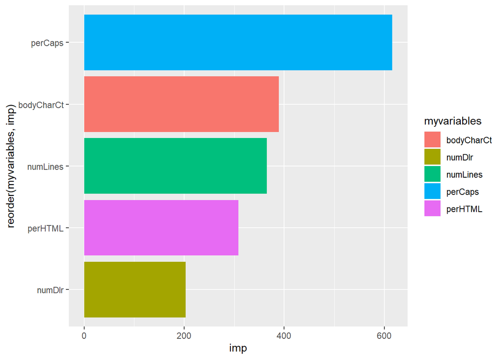

### Simple tuning

We do minor adjustments to our simple model by adjusting our complexity parameter.A high cp leads to a smaller tree and lower cp to larger tree.

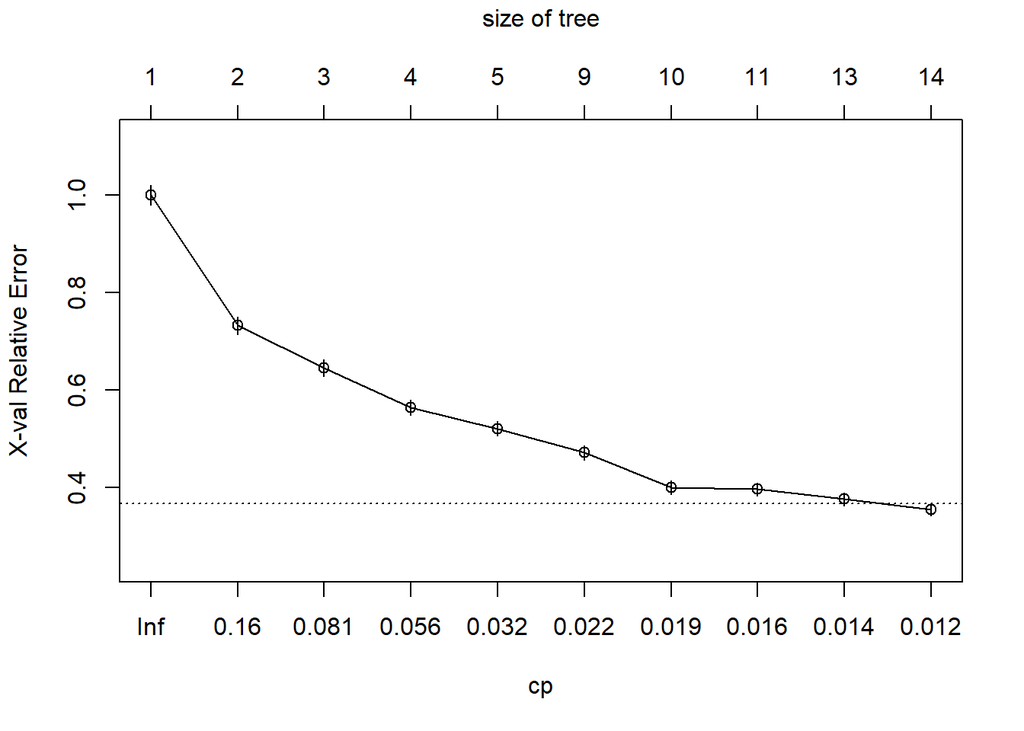

```r
plotcp(fit) # visualize cross-validation results
abline(v=.014, col="blue")
```

We want a complexity parameter that reduces our cross validation error. This value is computed by taking the average of a 10 fold cross validation error.

```r
printcp(fit)
```

```
##
## Classification tree:
## rpart(formula = isSpam ~ ., data = training, method = "class")
##
## Variables actually used in tree construction:
##  [1] bodyCharCt  forwards    isDear      isInReplyTo numDlr      numLines
##  [7] perCaps     perHTML     subBlanks   subExcCt
##
## Root node error: 1918/7479 = 0.25645
##
## n= 7479
##
##          CP nsplit rel error  xerror     xstd
## 1  0.283629      0   1.00000 1.00000 0.019689
## 2  0.090719      1   0.71637 0.73253 0.017612
## 3  0.072993      2   0.62565 0.64546 0.016758
## 4  0.042753      3   0.55266 0.56413 0.015861
## 5  0.024114      4   0.50991 0.52138 0.015346
## 6  0.020855      8   0.41345 0.47185 0.014705
## 7  0.017205      9   0.39260 0.40094 0.013695
## 8  0.015120     10   0.37539 0.39677 0.013631
## 9  0.013556     12   0.34515 0.37696 0.013324
## 10 0.010000     13   0.33160 0.35558 0.012980
```

We prune our tree based on the smallest cross validation error.

```r
# prune the tree
pfit<- prune(fit, cp=fit$cptable[which.min(fit$cptable[,"xerror"]),"CP"])
```

We test our accuracy on our pruned tree.

```
##    predict_test
##        F    T
##   F 1327   63
##   T  105  374
```

```
## [1] "Accuracy:  0.910112359550562"
```

We plot our pruned tree, but we didnt see major changes in our accuracy or tree plot. We further tune our model by testing different combinations of hyperparameters.

[figure not shown]

# CART Model with hyper parameter tuning

We will tune our model by training on different combinations of the hyperparameters below through a grid search approach.

- minsplit - minimum number of observations in a node required to attempts a split
- minbucket - minimum number of observations in any leaf
- cp - complexity parameter creates threshold, helps with pruning
- xval - cross validation
- maxdepth - depth of tree, or levels from root which starts at 0 to the level of our leaf nodes

We approach our hyperparameters using a grid search which creates a grid of 588 combinations of hyperparameters.

```r
models <- list()

hyper_grid <- expand.grid(
    minsplit = c(10,25, 50,100, 150, 250,500),
    minbucket = c(10,25, 50, 100,200,400,500),
    maxdepth = c(3, 5, 7, 10, 25,30),
#    cp = c(.001,.01,.1,.3),
    xval = c(3,5)

)

head(hyper_grid)
```

```
##   minsplit minbucket maxdepth xval
## 1       10        10        3    3
## 2       25        10        3    3
## 3       50        10        3    3
## 4      100        10        3    3
## 5      150        10        3    3
## 6      250        10        3    3
```

```r
for(i in 1:nrow(hyper_grid)) {

    # create parameter list

        minsplit = hyper_grid$minsplit[i]
        minbucket = hyper_grid$minbucket[i]
        maxdepth = hyper_grid$maxdepth[i]
#        cp = hyper_grid$cp[i]
        xval = hyper_grid$xval[i]

    # reproducibility
    set.seed(123)

    # train model
    models[[i]] <- rpart(formula = isSpam ~ .,
                         data=training,
                         method = "class",
                         minsplit=minsplit,
                         minbucket=minbucket,
                         maxdepth=maxdepth,
                    #     cp=cp,
                         xval=xval)

}
```

We generate several models given our different combinations of hyperparameters.

Example - Model 1

```
## n= 7479
##
## node), split, n, loss, yval, (yprob)
##       * denotes terminal node
##
##  1) root 7479 1918 F (0.74354860 0.25645140)
##    2) perCaps< 13.05174 6463 1138 F (0.82392078 0.17607922)
##      4) perHTML< 3.926441 5933  786 F (0.86752065 0.13247935) *
##      5) perHTML>=3.926441 530  178 T (0.33584906 0.66415094)
##       10) bodyCharCt>=13538 194   27 F (0.86082474 0.13917526) *
##       11) bodyCharCt< 13538 336   11 T (0.03273810 0.96726190) *
##    3) perCaps>=13.05174 1016  236 T (0.23228346 0.76771654)
##      6) bodyCharCt< 204 88    3 F (0.96590909 0.03409091) *
##      7) bodyCharCt>=204 928  151 T (0.16271552 0.83728448)
##       14) isInReplyTo=T 40    0 F (1.00000000 0.00000000) *
##       15) isInReplyTo=F 888  111 T (0.12500000 0.87500000) *
```

The functions below go through our models to find our optimal complexity parameter and minimum cross validation error with the given cp value.

```r
# function to get optimal cp
get_cp <- function(x) {
  min    <- which.min(x$cptable[, "xerror"])
  cp <- x$cptable[min, "CP"]
}

# function to get minimum error
get_min_error <- function(x) {
  min    <- which.min(x$cptable[, "xerror"])
  xerror <- x$cptable[min, "xerror"]
}

hyper_grid %>%
  mutate(
    cp    = purrr::map_dbl(models, get_cp),
    error = purrr::map_dbl(models, get_min_error)
    ) %>%
  arrange(error) %>%
  top_n(-5, wt = error)
```

```
##   minsplit minbucket maxdepth xval   cp     error
## 1       10        10       10    5 0.01 0.3477581
## 2       25        10       10    5 0.01 0.3477581
## 3       50        10       10    5 0.01 0.3477581
## 4       10        10       25    5 0.01 0.3477581
## 5       25        10       25    5 0.01 0.3477581
## 6       50        10       25    5 0.01 0.3477581
## 7       10        10       30    5 0.01 0.3477581
## 8       25        10       30    5 0.01 0.3477581
## 9       50        10       30    5 0.01 0.3477581
```

The list above shows our optimal model parameters and resulting cross validation error.

We apply the parameters below.

- minsplit = 10
- minbucket = 10
- maxdepth = 10
- xval = 5
- cp = .01

```r
optimal_model <- rpart(formula = isSpam ~ .,
                         data=training,
                         method = "class",
                         minsplit=10,
                         minbucket=10,
                         maxdepth=10,
                         cp=.01,
                         xval=5)
```

Tuning on our hyperparameters does not significantly improve our model nor reduce the complexity of our decision tree. We tune further using the Caret package to find an optimal complexity parameter for pruning our tree and also max-depth.

```
##    predict_test
##        F    T
##   F 1327   63
##   T  105  374
```

```
## [1] "Accuracy:  0.910112359550562"
```

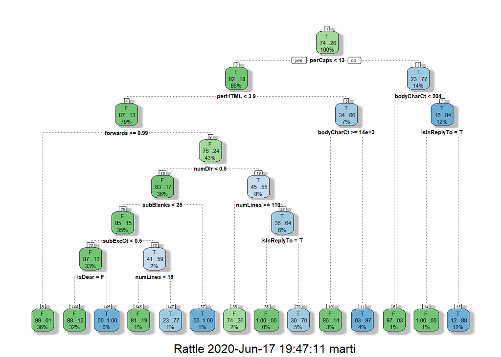

# Caret Approach to tuning

With package Caret we can tune to find an optimal complexity parameter. This is done by setting our method to ‘rpart’ and creating a smaller grid for the different cp values. Caret only allows tuning on either complexity parameters or max-depth via the method type. For tuning for cp we use method type “rpart”.

We find that a lower complexity parameter of .001 returns a more accurate model.

```r
# Create a trainControl object to control how the train function creates the model
train_control <- trainControl(method = "cv",   # Use cross validation
                              number = 5             # Use 10 partitions
                              )             # Repeat 2 times

# Set required parameters for the model type we are using**
tune_grid = expand.grid(
    cp = c(.001,.01,.1,.3,.5)
    )


# Use the train() function to create the model
validated_tree <- train(isSpam ~ .,
                        data=training,                 # Data set
                        method="rpart",                     # Model type(decision tree)
                        trControl= train_control,           # Model control options
                        tuneGrid = tune_grid,
                        na.action = na.pass)               # Required model parameters

validated_tree         # View a summary of the model
```

```
## CART
##
## 7479 samples
##   29 predictor
##    2 classes: 'F', 'T'
##
## No pre-processing
## Resampling: Cross-Validated (5 fold)
## Summary of sample sizes: 5983, 5983, 5983, 5983, 5984
## Resampling results across tuning parameters:
##
##   cp     Accuracy   Kappa
##   0.001  0.9362220  0.8305532
##   0.010  0.9109509  0.7623388
##   0.100  0.8196284  0.4472180
##   0.300  0.7435486  0.0000000
##   0.500  0.7435486  0.0000000
##
## Accuracy was used to select the optimal model using the largest value.
## The final value used for the model was cp = 0.001.
```

```r
# Create a trainControl object to control how the train function creates the model
train_control <- trainControl(method = "cv",   # Use cross validation
                              number = 5             # Use 10 partitions
                              )             # Repeat 2 times

# Set required parameters for the model type we are using**
tune_grid = expand.grid(
    maxdepth = c(3:25)
    )


# Use the train() function to create the model
validated_tree <- train(isSpam ~ .,
                        data=training,                 # Data set
                        method="rpart2",                     # Model type(decision tree)
                        trControl= train_control,           # Model control options
                        tuneGrid = tune_grid,
                        na.action = na.pass)               # Required model parameters

validated_tree         # View a summary of the model
```

```
## CART
##
## 7479 samples
##   29 predictor
##    2 classes: 'F', 'T'
##
## No pre-processing
## Resampling: Cross-Validated (5 fold)
## Summary of sample sizes: 5983, 5984, 5982, 5984, 5983
## Resampling results across tuning parameters:
##
##   maxdepth  Accuracy   Kappa
##    3        0.8527876  0.5714604
##    4        0.8622793  0.5919164
##    5        0.8805971  0.6630804
##    6        0.8856775  0.6858091
##    7        0.8891557  0.6994044
##    8        0.8891557  0.6994044
##    9        0.8898237  0.7009477
##   10        0.8959747  0.7158335
##   11        0.9066754  0.7504644
##   12        0.9098830  0.7600740
##   13        0.9108188  0.7627890
##   14        0.9132261  0.7701561
##   15        0.9145639  0.7741374
##   16        0.9153665  0.7764523
##   17        0.9155003  0.7768406
##   18        0.9155003  0.7768406
##   19        0.9155003  0.7768406
##   20        0.9155003  0.7768406
##   21        0.9155003  0.7768406
##   22        0.9155003  0.7768406
##   23        0.9155003  0.7768406
##   24        0.9155003  0.7768406
##   25        0.9155003  0.7768406
##
## Accuracy was used to select the optimal model using the largest value.
## The final value used for the model was maxdepth = 17.
```

```r
optimal_model2 <- rpart(formula = isSpam ~ .,
                         data=training,
                         method = "class",
                         minsplit=10,
                         minbucket=10,
                         maxdepth=12,
                         cp=.001,
                         xval=5)
```

WApplying the new cp and maxdepth increases our accuracy to 94% when applied to our test set. The resulting tree however is more complex as our cp threshold is lower allowing for a more complex tree as seen below.

```
##    predict_test
##        F    T
##   F 1345   45
##   T   64  415
```

```
## [1] "Accuracy:  0.941680042803638"
```

[figure not shown]

The most important feature is the percentage of capital letters in our email’s body. This feature helps create optimal splits and is found to create lower gini index when the feature acts as a primary or surrogate feature. Another important feature is the number of characters in the body of the email, this feature is “important” as it helps contribute to more homogenous splits across our tree when compared to other predictor variables.

- Top 5 variables by variable importance
  - 1. perCaps - percentage of capital letters in the email body
  - 2. bodyCharct - number of characters in the email body
  - 3. numLines - number of lines in the email body
  - 4. perHTML - percent of characters with html tags
  - 5. numDlr - number of dollar signs in the email body

```
## label_key: myvariables
```

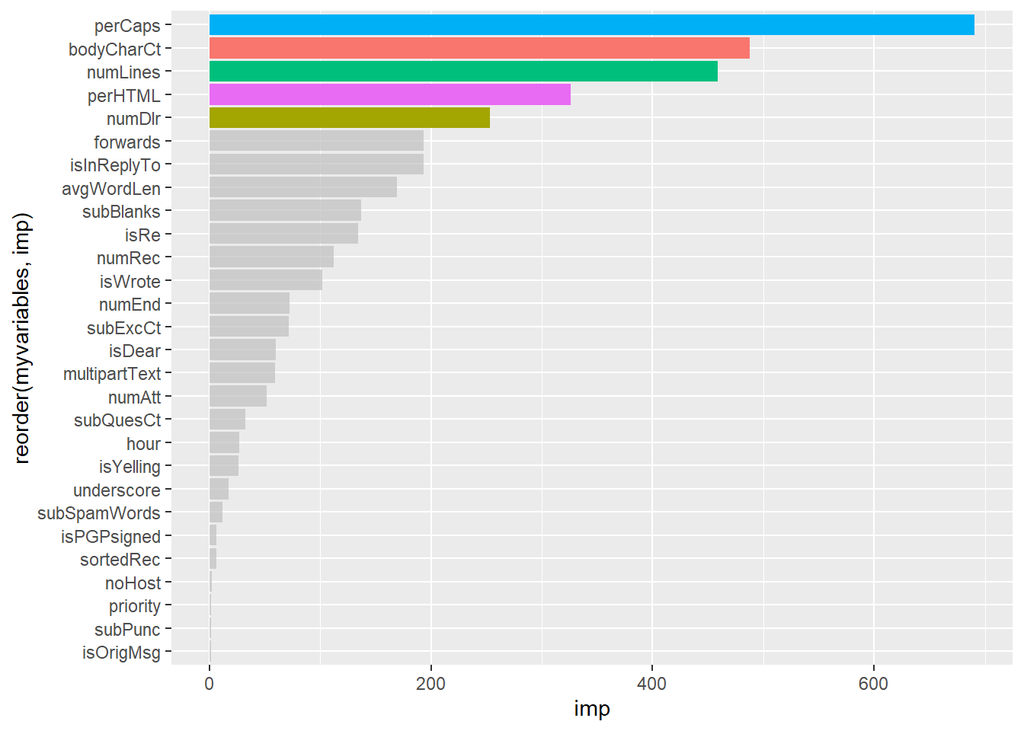

The trade-off of a tuned model is an increased accuracy, however this results in a very cumbersome tree with many leaf nodes and depth. Translating the tree to a non-technical audience would be close to impossible without putting them to sleep. However our accuracy would shine as our business partners may only be interested in how well our model performs and not the guts of our tree.